# assignment06

Jeff Nguyen

09/10/2020

**University of Southern California**  
**Marshall School of Business**  
**FBE 506 Quantitative Method in Finance**

Assignment 06  
Student Name: Ngoc Son (Jeff) Nguyen  
Student ID: 6524885309

# **Question 1**

$$\begin{equation}
\begin{aligned}
Q = 150*N - .025*N^2
\end{aligned}
\end{equation}$$

## a. Finding optimum N and Q. No constraint.

Objective is to maximize Q given N. Thus we find the max of Q. Q(N) is a polynomial function, and thus, continuous everywhere.

**Graph of the function:**

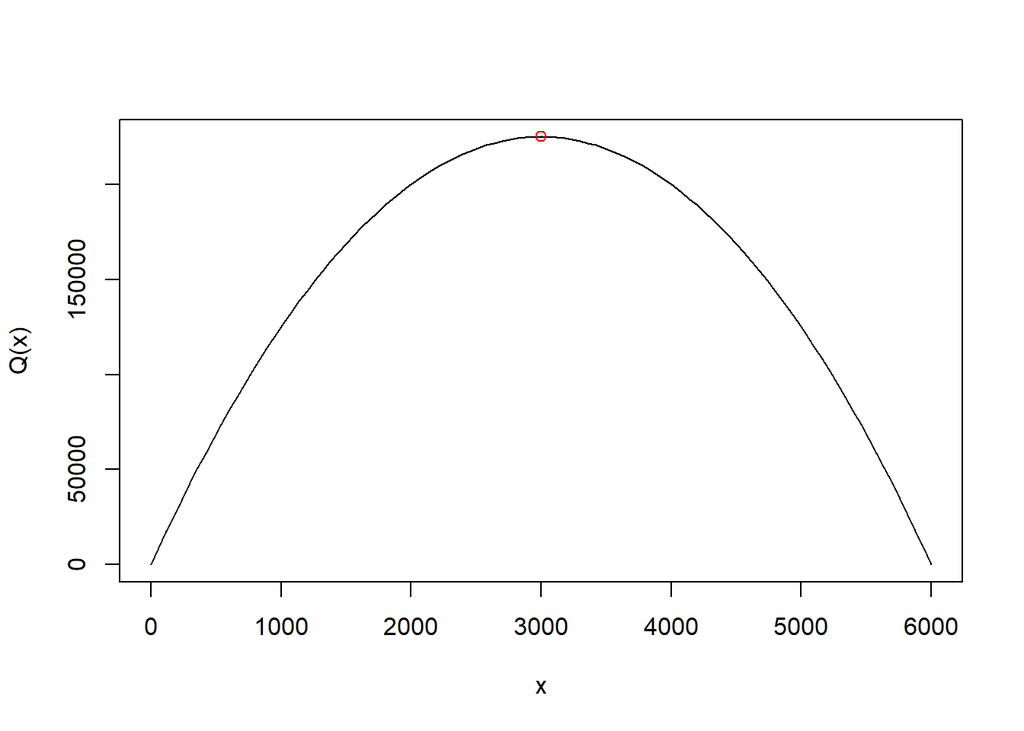

```r
Q <- function(N) 150*N - .025*N^2
curve(Q, 0, 6000)
root <- polyroot(c(150, -.05))
N_max <- Re(root)[abs(Im(root)) < 1e-6]
Q_max <- Q(N_max)
points(N_max, Q(N_max), col='red')
```

We know:
$$\begin{equation}
\begin{aligned}
Q'(N_0) & = 0 \\
\frac{dQ}{dN} & = 0 \\
150 - .05*N_{max} & = 0 \\
N_{max} & = 3000
\end{aligned}
\end{equation}$$

**Per graph, we can confirm Q(N) optimum is at $N_{max} = 3000$ and $Q_{max} = 2.25\times 10^{5}$.**

## b,c,d. Finding optimum N and Q. Constraint $N \leqslant 250$.

The problem is to maximize the output $Q$ subject to the constraint that the business can not have more than 250 units of labor $N$.  
To solve the constrained optimizing problem, we form the Lagrangian function.

**The Lagrangian function is formed by augmenting the constraint together with the Lagrange multiplier to the objective function.**

$$\begin{equation}
\begin{aligned}
L = 150*N - .025*N^2 + \lambda*(250 - N)
\end{aligned}
\end{equation}$$

If the constraint is satisfied, no matter what value has, the second term in the right side of the Lagrangian equation will vanish and we arrive at $L = 150*N - .025*N^2$, that is maximizing $L$ with respect to $N$ is the same as maximizing $Q$, and achieving the objective. Therefore, the trick in solving a constrained optimizing problem is to incorporate the constraint into the problem and ensure that the constraint is satisfied with equality. This is done by treating $\lambda$ as an additional variable and assuming $L$ is a function of $N$ and $\lambda$. That is:

$$\begin{equation}
\begin{aligned}
L(N, \lambda) = 150*N - .025*N^2 + \lambda*(250 - N)
\end{aligned}
\end{equation}$$

Differentiating $L$ with respect to $N$:
$$\begin{equation}
\begin{aligned}
L'(N_0) & = 0 \\
\frac{dL}{dN} & = 0 \\
150 - .05*N_0 - \lambda & = 0 \quad \text{(1)} \\
\end{aligned}
\end{equation}$$

Differentiating $L$ with respect to $\lambda$:
$$\begin{equation}
\begin{aligned}
L'(\lambda) & = 0 \\
\frac{dL}{d\lambda} & = 0 \\
250 - N_0 & = 0 \\
N_0 & = 250 \quad \text{(2)}
\end{aligned}
\end{equation}$$

Substitute (2) to (1), we have $\lambda = 137.5 > 0$.  
The Lagrangian multiplier $\lambda$ is positive, implying the constraint is binding.

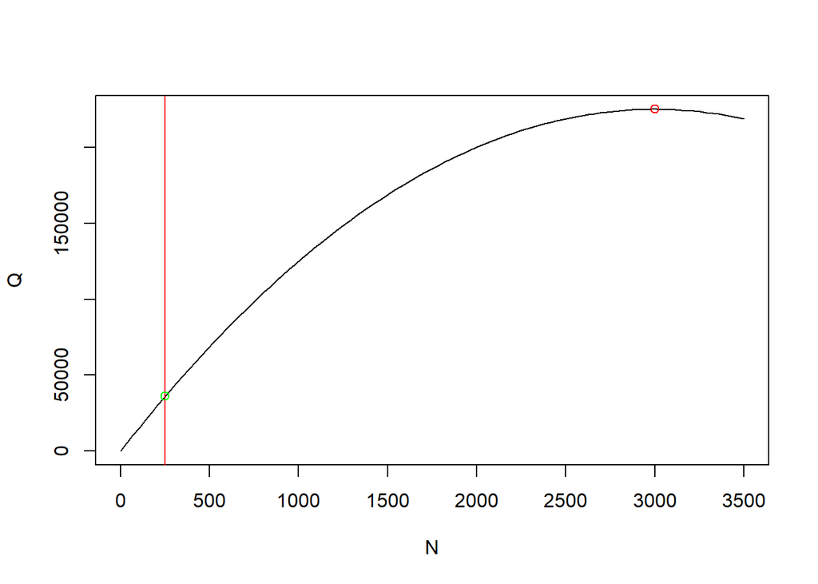

```r
N_0 <- 250
Q_0 <- Q(N_0)
plot(Q, 0, 3500, xlab = 'N', ylab = 'Q')
abline(v = 250, col = 'red')
points(N_0, Q(N_0), col = 'green')
points(N_max, Q(N_max), col='red')
```

Therefore, the optimum solution to this problem is $N_0 = 250$ and $Q_0 = 3.59375\times 10^{4}$.

# **Question 2**

$$\begin{equation}
\begin{aligned}
Y = X^3 -11*X^2 + 14*X + 80
\end{aligned}
\end{equation}$$

```r
f <- function(x) x^3 -11*x^2 + 14*x + 80
f_1prime <- function(x) 3*x^2 - 22*x + 14
root <- polyroot(c(14, -22, 3))
x_1prime <- Re(root)[abs(Im(root)) < 1e-6]
x_1prime
```

```
## [1] 0.7039352 6.6293981
```

This is a polynomial function, thus, it is continuous everywhere.  
We know:

$$\begin{equation}
\begin{aligned}
f'(x_0) & = 0 \\
\frac{dy}{dx} & = 0 \\
3*x^2 - 22*x + 14 & = 0 \\
x_0 & = 0.7039352, 6.6293981
\end{aligned}
\end{equation}$$

```r
x_1prime1 <- 0.7039352
x_1prime2 <- 6.6293981
```

Testing min, max with $x_0 = 0.7039352$
$$\begin{equation}
\begin{aligned}
f'(x_0 - 1) & = f'(-0.2960648) \qquad & f'(x_0 + 1) & = f'(1.7039352) \\
f'(x_0 - 1) & = 3*(-0.2960648)^2 - 22*(-0.2960648) + 14 & f'(x_0 + 1) & = 3*(1.7039352)^2 - 22*(1.7039352) + 14 \\
f'(x_0 - 1) & = 20.7763887 > 0 & f'(x_0 + 1) & = -14.7763889 < 0
\end{aligned}
\end{equation}$$

Finding $f(0.7039352)$:
$$\begin{equation}
\begin{aligned}
f(0.7039352) & = 0.7039352^3 -11*0.7039352^2 + 14*0.7039352 + 80 \\
f(0.7039352) & = 84.7531377
\end{aligned}
\end{equation}$$

**From the above, we know the function has a local maxima at $(0.7039352, 84.7531377)$**

Testing min, max with $x_0 = 6.6293981$
$$\begin{equation}
\begin{aligned}
f'(x_0 - 1) & = f'(5.6293981) \qquad & f'(x_0 + 1) & = f'(7.6293981) \\
f'(x_0 - 1) & = 3*(5.6293981)^2 - 22*(5.6293981) + 14 & f'(x_0 + 1) & = 3*(7.6293981)^2 - 22*(7.6293981) + 14 \\
f'(x_0 - 1) & = -14.7763893 < 0 & f'(x_0 + 1) & = 20.7763879 > 0
\end{aligned}
\end{equation}$$

Finding $f(6.6293981)$:
$$\begin{equation}
\begin{aligned}
f(6.6293981) & = 6.6293981^3 -11*6.6293981^2 + 14*6.6293981 + 80 \\
f(6.6293981) & = -19.2716562
\end{aligned}
\end{equation}$$

**From the above, we know the function has a local minima at $(6.6293981, -19.2716562)$**

Finding inflection point:
$$\begin{equation}
\begin{aligned}
f''(x_0) & = 0 \\
\frac{d^2 y}{dx^2} & = 0 \\
6x - 22 & = 0 \\
x & = \frac{11}{3} \approx 3.666667
\end{aligned}
\end{equation}$$

```r
x_2prime1 <- 11/3
f_2prime <- function(x) 6*x - 22
```

Testing the potential inflection point at $x_0 = 3.6666667$
$$\begin{equation}
\begin{aligned}
f''(x_0 - 1) & = f''(2.6666667) \qquad & f''(x_0 + 1) & = f''(4.6666667) \\
f''(x_0 - 1) & = 6*2.6666667 - 22 & f''(x_0 + 1) & = 6*4.6666667 - 22 \\
f''(x_0 - 1) & = -6 < 0 & f''(x_0 + 1) & = 6 > 0
\end{aligned}
\end{equation}$$

Finding $f(3.6666667)$:
$$\begin{equation}
\begin{aligned}
f(3.6666667) & = 3.6666667^3 -11*3.6666667^2 + 14*3.6666667 + 80 \\
f(3.6666667) & = 32.7407407
\end{aligned}
\end{equation}$$

**From the test, we see that the function curvature changes from concave to convex at $(3.6666667,32.7407407)$, thus $(3.6666667,32.7407407)$ is an inflection point.**

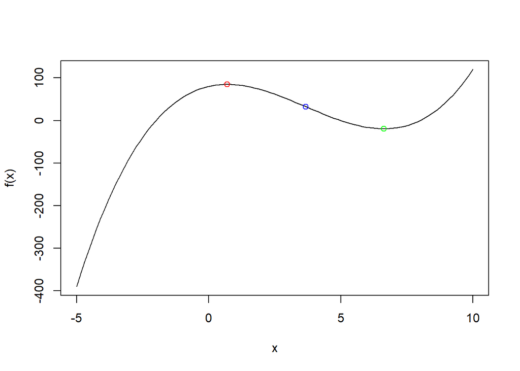

```r
x_1prime1 <- 0.7039352
x_1prime2 <- 6.6293981
x_2prime1 <- 11/3
curve(f, -5, 10)
points(x_1prime1, f(x_1prime1), col = 'red')
points(x_1prime2, f(x_1prime2), col = 'green')
points(x_2prime1, f(x_2prime1), col = 'blue')
```

# **Question 3**

$$\begin{equation}
\begin{aligned}
Q = 100*N + 10*N^2 - N^3
\end{aligned}
\end{equation}$$

**Graph of the function:**

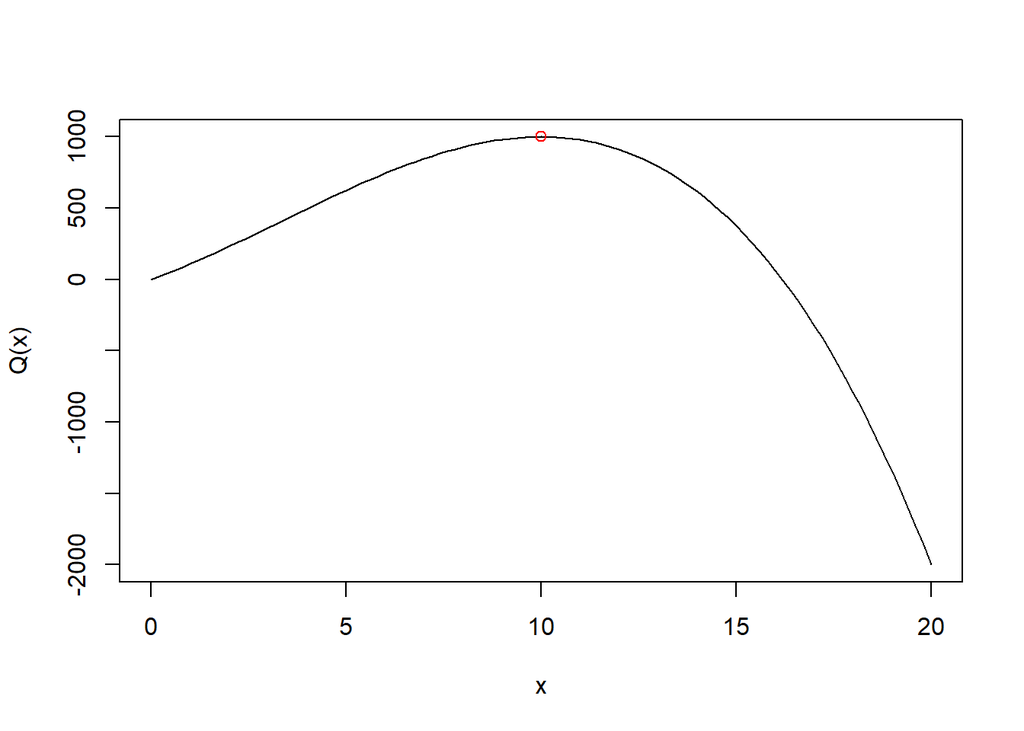

```r
Q <- function(N) 100*N + 10*N^2 - N^3
curve(Q, 0, 20)
root <- polyroot(c(100, 20, -3))
N_max <- Re(root)[abs(Im(root)) < 1e-6]
N_max <- N_max[which(N_max>0)]
Q_max <- Q(N_max)
points(N_max, Q(N_max), col='red')
```

Considering the solution with no constraint:

We know:
$$\begin{equation}
\begin{aligned}
Q'(N_max) & = 0 \\
\frac{dQ}{dN} & = 0 \\
100 + 20 * N_{max} - 3*N^2 & = 0 \\
N_{max} & = 10
\end{aligned}
\end{equation}$$

**Per graph, we can confirm Q(N) optimum is at $N_{max} = 10$ and $Q_{max} = 1000$.**

## a,b. Finding optimum N and Q. Constraint $N \leqslant 15$.

The problem is to maximize the output $Q$ subject to the constraint that the business can not have more than 15 units of labor $N$.  
To solve the constrained optimizing problem, we form the Lagrangian function.

**The Lagrangian function is formed by augmenting the constraint together with the Lagrange multiplier to the objective function.**

$$\begin{equation}
\begin{aligned}
L = 100*N + 10*N^2 - N^3 + \lambda*(15 - N)
\end{aligned}
\end{equation}$$

If the constraint is satisfied, no matter what value has, the second term in the right side of the Lagrangian equation will vanish and we arrive at $L = 100*N + 10*N^2 - N^3$, that is maximizing $L$ with respect to $N$ is the same as maximizing $Q$, and achieving the objective. Therefore, the trick in solving a constrained optimizing problem is to incorporate the constraint into the problem and ensure that the constraint is satisfied with equality. This is done by treating $\lambda$ as an additional variable and assuming $L$ is a function of $N$ and $\lambda$. That is:

$$\begin{equation}
\begin{aligned}
L(N, \lambda) = 100*N + 10*N^2 - N^3 + \lambda*(15 - N)
\end{aligned}
\end{equation}$$

Differentiating $L$ with respect to $N$:
$$\begin{equation}
\begin{aligned}
L'(N_0) & = 0 \\
\frac{dL}{dN} & = 0 \\
100- \lambda + 20*N - 3*N^2 & = 0 \quad \text{(1)} \\
\end{aligned}
\end{equation}$$

Differentiating $L$ with respect to $\lambda$:
$$\begin{equation}
\begin{aligned}
L'(\lambda) & = 0 \\
\frac{dL}{d\lambda} & = 0 \\
15 - N_0 & = 0 \\
N_0 & = 15 \quad \text{(2)}
\end{aligned}
\end{equation}$$

Substitute (2) to (1), we have $\lambda = -275 < 0$.  
The Lagrangian multiplier $\lambda$ is negative, implying the constraint is non-binding.  
**Therefore, the constraint does not affect the optimum solution, which is still $N_{max} = 10$ and $Q_{max} = 1000$.**

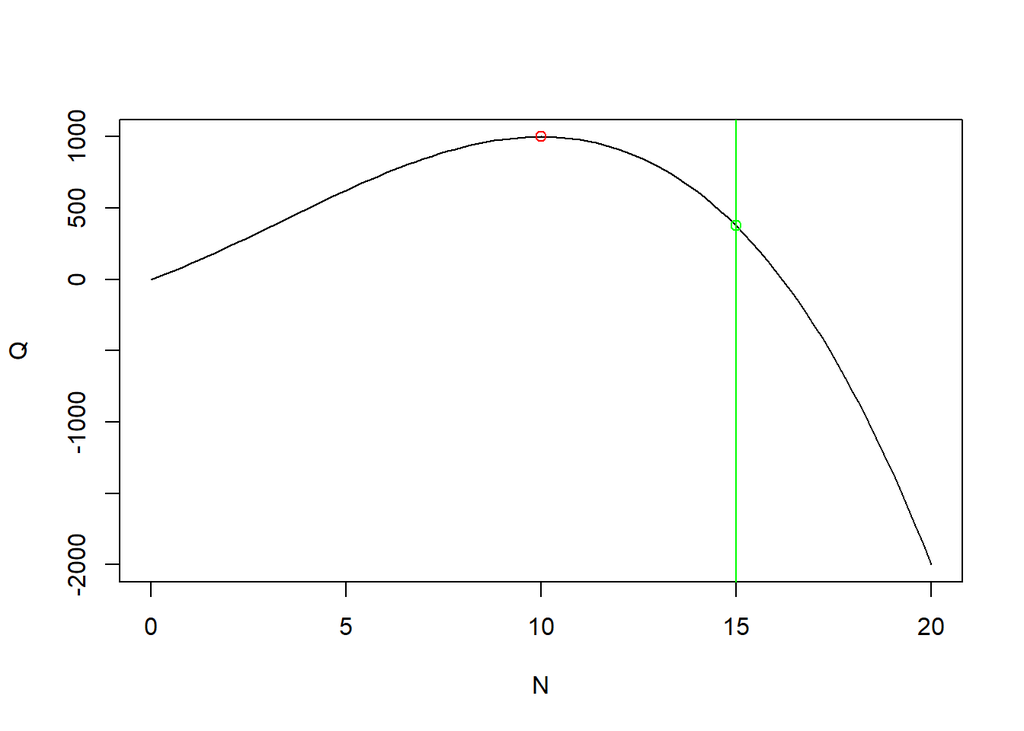

```r
N_0 <- 15
lambda <- 100 + 20*N_0 - 3*N_0^2
Q_0 <- Q(N_0)
plot(Q, 0, 20, xlab = 'N', ylab = 'Q')
abline(v = N_0, col = 'green')
points(N_0, Q(N_0), col = 'green')
points(N_max, Q(N_max), col='red')
```

## c,d. Finding optimum N and Q. Constraint $N \leqslant 8$.

The problem is to maximize the output $Q$ subject to the constraint that the business can not have more than 8 units of labor $N$.  
To solve the constrained optimizing problem, we form the Lagrangian function.

**The Lagrangian function is formed by augmenting the constraint together with the Lagrange multiplier to the objective function.**

$$\begin{equation}
\begin{aligned}
L = 100*N + 10*N^2 - N^3 + \lambda*(8 - N)
\end{aligned}
\end{equation}$$

If the constraint is satisfied, no matter what value has, the second term in the right side of the Lagrangian equation will vanish and we arrive at $L = 100*N + 10*N^2 - N^3$, that is maximizing $L$ with respect to $N$ is the same as maximizing $Q$, and achieving the objective. Therefore, the trick in solving a constrained optimizing problem is to incorporate the constraint into the problem and ensure that the constraint is satisfied with equality. This is done by treating $\lambda$ as an additional variable and assuming $L$ is a function of $N$ and $\lambda$. That is:

$$\begin{equation}
\begin{aligned}
L(N, \lambda) = 100*N + 10*N^2 - N^3 + \lambda*(8 - N)
\end{aligned}
\end{equation}$$

Differentiating $L$ with respect to $N$:
$$\begin{equation}
\begin{aligned}
L'(N_0) & = 0 \\
\frac{dL}{dN} & = 0 \\
100- \lambda + 20*N - 3*N^2 & = 0 \quad \text{(1)} \\
\end{aligned}
\end{equation}$$

Differentiating $L$ with respect to $\lambda$:
$$\begin{equation}
\begin{aligned}
L'(\lambda) & = 0 \\
\frac{dL}{d\lambda} & = 0 \\
8 - N_0 & = 0 \\
N_0 & = 8 \quad \text{(2)}
\end{aligned}
\end{equation}$$

Substitute (2) to (1), we have $\lambda = 68 > 0$.  
The Lagrangian multiplier $\lambda$ is positive, implying the constraint is binding.

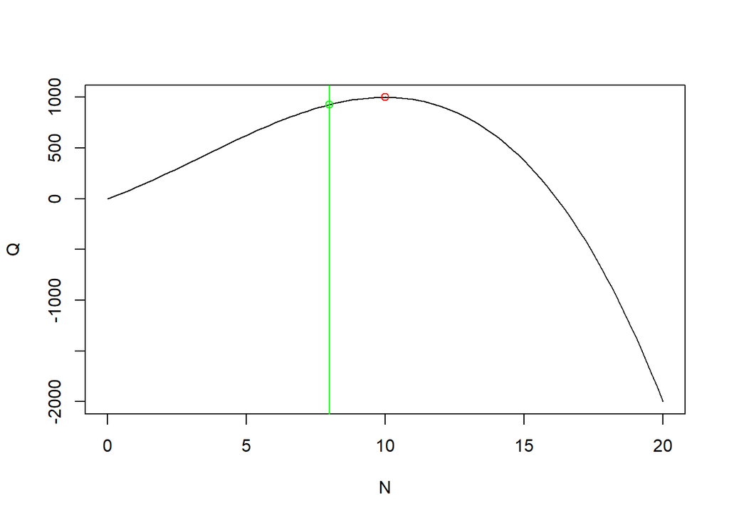

```r
N_0 <- 8
lambda <- 100 + 20*N_0 - 3*N_0^2
Q_0 <- Q(N_0)
plot(Q, 0, 20, xlab = 'N', ylab = 'Q')
abline(v = N_0, col = 'green')
points(N_0, Q(N_0), col = 'green')
points(N_max, Q(N_max), col='red')
```

**Therefore, the constraint does affect the optimum solution, which is now $N_0 = 8$ and $Q_0 = 928$.**

# **Question 4**

## a. Find the GMV solution, no short sale.

Given parameters

```r
# Mean Returns
mean_rStock1 <- .13
mean_rStock2 <- .21
mean_rf <- .08

# Variance of returns
var_rStock1 <- .075
var_rStock2 <- .052

# Standard deviation of returns
sd_rStock1 <- sqrt(var_rStock1)
sd_rStock2 <- sqrt(var_rStock2)

# Covariance of Returns
cov_rStock1_rStock2 <- .018

# Correlation of Returns
cor_rStock2_rStock2 <- cov_rStock1_rStock2 / (sd_rStock1 * sd_rStock2)
```

| Asset | Mean Returns | Variance | Pair | $\sigma_{1,2}$ |
| --- | --- | --- | --- | --- |
| Stock 1 | 0.13 | 0.075 | (1,2) | 0.018 |
| Stock 2 | 0.21 | 0.052 |  |  |
| Risk Free | 0.08 |  |  |  |

Since the investor’s objective is to minimize risk, we solve for the global minimum variance combination of the two assets. Let $x_i$ denotes the weight of the investment in asset i $(i = 1,2)$, and assume all money is invested in i, meaning $\sum {x_i} = x_1 + x_2 = 1$.

$$\begin{equation}
\begin{aligned}
\text {The returns of the portfolio is:} \\
R_{p,x} & = x_1 * r_1 + x_2 * r_2 \\
\text {The expected returns on the portfolio is:} \\
\mu_{p,x} & = E[R_{p,x}] \\
& = x_1 * \mu_1 + x_2 * \mu_2 \\
\text {The variance of the portfolio returns is:} \\
\sigma_{p,x}^2 & = var(R_{p,x}) \\
& = x_1 * \sigma_1^2 + x_2 * \sigma_2^2 + 2 * x_1 * x_2 * \sigma_{1,2}
\end{aligned}
\end{equation}$$

The global minimum variance portfolio $m = (m_1,m_2)$ is the solution of the constrained minimization problem:

$$\begin{equation}
\begin{aligned}
min \sigma_{p,m}^2 & = var(R_{p,m}) \\
& = m_1^2 * \sigma_1^2 + m_2^2 * \sigma_2^2 + 2 * m_1 * m_2 * \sigma_{1,2} \\
\text {s.t. } m_1 + m_2 & = 1 \\
\text {rewrite: } \\
min \sigma_{p,m}^2 & = min[m_1^2 * \sigma_1^2 + (1-m_1)^2 * \sigma_2^2 + 2 * m_1 * (1 - m_1) * \sigma_{1,2}] \\
& = min[m_1^2 * (\sigma_1^2 + \sigma_2^2 - 2 * \sigma_{1,2}) + m_1 * (2 * \sigma_{1,2} - 2 * \sigma_2^2) + \sigma_2^2] \\
\text {plug in: }
min \sigma_{p,m}^2 & = min[(0.075 + 0.052 - 2 * 0.018) * m_1^2 + (2*0.018 - 2*0.052) * m_1 + 0.052] \\
min \sigma_{p,m}^2 & = min[(0.091) * m_1^2 + (-0.068) * m_1 + 0.052] \\
\end{aligned}
\end{equation}$$

Find the critical point:

$$\begin{equation}
\begin{aligned}
\frac{d\sigma_{p,m}^2}{dm} & = 0 \\
\frac{d(0.091 * m_1^2 + (-0.068) * m_1 + 0.052)}{dm} & = 0 \\
.182* m_1 - .068 & = 0 \\
m_1 & = .3736 = 37.36\% \\
\text {thus, } \\
m_2 & = 1 - 0.3736 = .6264 = 62.64\%
\end{aligned}
\end{equation}$$

**Recap:**

| Asset | Weight |
| --- | --- |
| Stock 1 | `37.36`% |
| Stock 2 | `62.64`% |

Graphing the function:

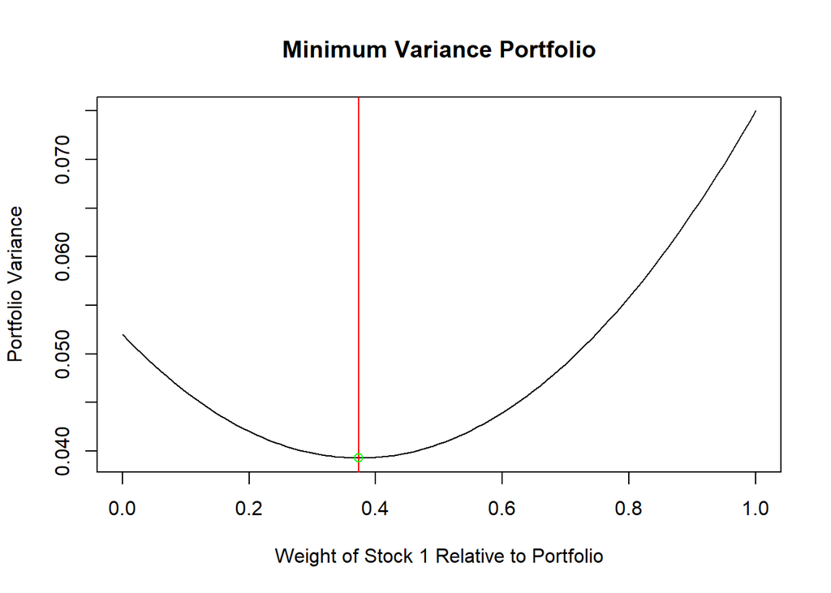

```r
# The Variance function of the portfolio
fVar <- function(m1) var_rStock1 * m1^2 + var_rStock2 * (1 - m1)^2 + 2 * m1 * (1 - m1) * cov_rStock1_rStock2

# Set the weighting
m1 <- .3736
m2 <- .6264

# Plot of the variance function with respect to w1.
w1 <- seq(0, 1, .05)
plot(fVar, w1, xlab = "Weight of Stock 1 Relative to Portfolio", ylab = "Portfolio Variance", main = "Minimum Variance Portfolio"); abline(v = m1, col = "red")
points(m1, fVar(m1), col='green')
```

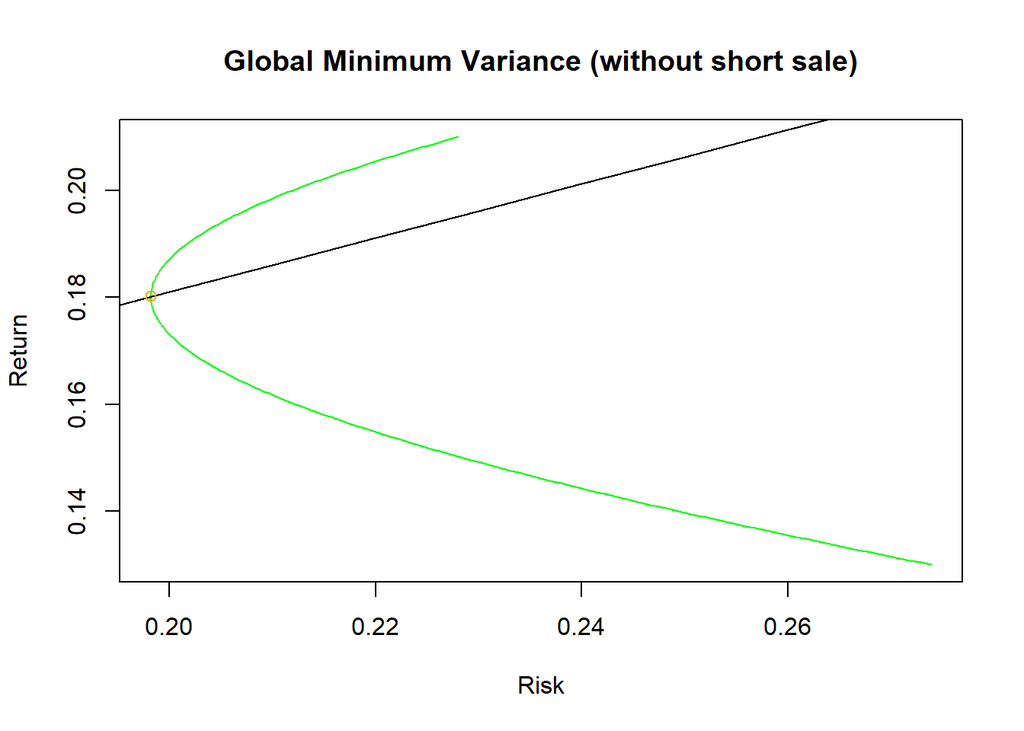

```r
# Plot of the efficient frontier, assume no short sale allowed
w1WithoutShort <- seq(0, 1, .005)
fVar <- function(w1) var_rStock1 * w1^2 + var_rStock2 * (1 - w1)^2 + 2 * w1 * (1 - w1) * cov_rStock1_rStock2
r <- function(w1) mean_rStock1*w1 + mean_rStock2*(1-w1)
riskWithoutShort <- sqrt(fVar(w1WithoutShort))
returnWithoutShort <- r(w1WithoutShort)
plot(riskWithoutShort, returnWithoutShort, type='l', main='Global Minimum Variance (without short sale)', xlab = 'Risk', ylab = 'Return', col = 'green')
wp <- (var_rStock2 - cov_rStock1_rStock2) / (var_rStock1 + var_rStock2 - 2 * cov_rStock1_rStock2)  # Normalizing weight
Rp <- r(wp)
sigma <- sqrt(fVar(wp))
Rf <- mean_rf
Sharpe <- (Rp-Rf)/sigma
X <- seq(0, 1, .01)
Y <- Rf + Sharpe*X
lines(X, Y)
points(sigma, Rp, col='orange')
```

We see indeed the minimum is at $m_1 = 0.3736$

Thus, the optimum weights of each stocks in the portfolio to satisfy the objective of minimum risk is:

| Asset | Weight | Risk | Return |
| --- | --- | --- | --- |
| Stock 1 | 37.36% |  |  |
| Stock 2 | 62.64% |  |  |
| Portfolio | 100% | 0.198234 | 0.1801099 |

## **b. Construct the efficient frontier. Assume short sale.**

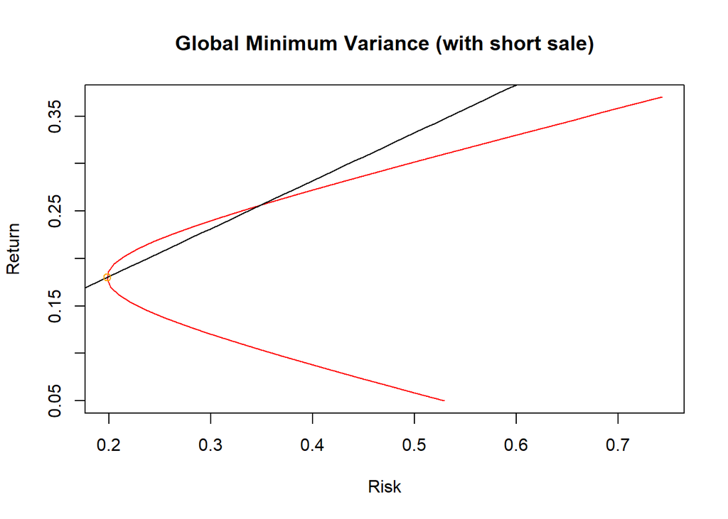

```r
# Plot of the efficient frontier, assume short sale allowed
w1WithShort <- seq(-2, 2, .1)
riskWithShort <- sqrt(fVar(w1WithShort))
returnWithShort <- r(w1WithShort)
plot(riskWithShort, returnWithShort, type='l', main='Global Minimum Variance (with short sale)', xlab = 'Risk', ylab = 'Return', col = 'red')
wp <- (var_rStock2 - cov_rStock1_rStock2) / (var_rStock1 + var_rStock2 - 2 * cov_rStock1_rStock2)  # Normalizing weight
Rp <- r(wp)
sigma <- sqrt(fVar(wp))
Rf <- mean_rf
Sharpe <- (Rp-Rf)/sigma
X <- seq(0, 1, .01)
Y <- Rf + Sharpe*X
lines(X, Y)
points(sigma, Rp, col='orange')
```

## c. **Graph the efficient frontier of portfolio with and without short sale together.**

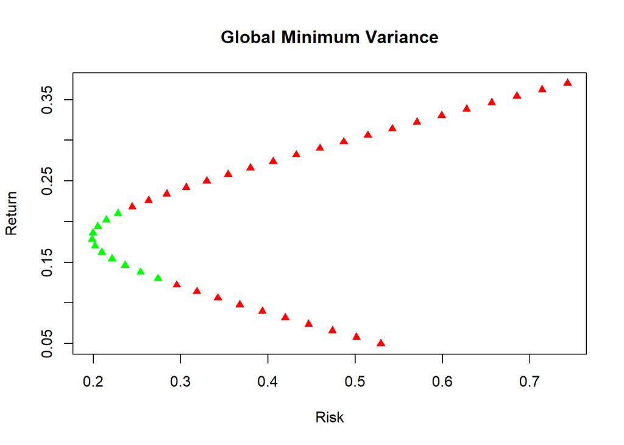

```r
# Changed input to display less points
w1WithoutShort <- seq(0, 1, .1)
riskWithoutShort <- sqrt(fVar(w1WithoutShort))
returnWithoutShort <- r(w1WithoutShort)
w1WithShort <- seq(-2, 2, .1)
riskWithShort <- sqrt(fVar(w1WithShort))
returnWithShort <- r(w1WithShort)


plot(riskWithShort, returnWithShort, main='Global Minimum Variance', xlab = 'Risk', ylab = 'Return', col = 'red', pch = 17)
points(riskWithoutShort, returnWithoutShort, col = 'green', pch = 17)
```

## d. **Find the GMV solution with additional constraint that $R_p > r_f$**

Not dissimilar to 4a, the investor’s objective is to minimize risk with a constrained on expected returns $R_p > r_f$, we solve for the global minimum variance combination of the two assets.

Let $w_i$ denotes the weight of the investment in asset i $(i = 1,2)$, and assume all money is invested in i, meaning $\sum {w_i} = w_1 + w_2 = 1$.

Formulating the Markowitz portfolio problem:

$$\begin{equation}
\begin{aligned}
\text {The investor's objective is:} \\
max \mu_p & = w' * \mu \quad \text{s.t.} \\
\sigma_p^2 & = w' * (\sum) * w \quad \text{and} \quad w'*I = 1 \\
\text {where:} \\
w & = \quad \text{matrix of asset weights in the portfolio} \\
& =
\begin{pmatrix}
w_1 \\
w_2 \\
\end{pmatrix} \\
w' & = \quad \text{transpose matrix of asset weights in the portfolio} \\
& =
\begin{pmatrix}
w_1 & w_2 \\
\end{pmatrix} \\
\mu & = \quad \text{matrix of mean returns of asset in the portfolio} \\
& =
\begin{pmatrix}
\mu_1 \\
\mu_2 \\
\end{pmatrix} \\
\sum & = \quad \text{Variance-covariance matrix of asset returns in the the portfolio} \\
& =
\begin{pmatrix}
\sigma_1 & \sigma_{1,2} \\
\sigma_{1,2} & \sigma_2 \\
\end{pmatrix} \\
w'*I & = \sum_{i=1}^{n} w_n \quad \text{or the sum weights of the asset in the portfolio, I is notation for identity matrix} \\
\end{aligned}
\end{equation}$$

Let $\mu_{p,0}$ denotes a target expected return level. Formulate the problem:

$$\begin{equation}
\begin{aligned}
min \sigma_{p,w}^2 & = w' * (\sum) * w \quad \text{s.t.} \\
\mu_p & = w' * \mu = \mu_{p,0}, \quad \text{and} \quad w'*I = 1 \\
\end{aligned}
\end{equation}$$

To solve this, form the Lagrangian function:

$$\begin{equation}
\begin{aligned}
L(w, \lambda_1, \lambda_2) & = w'*\sum*w + \lambda_1*(w'*\mu - \mu_{p,0}) + \lambda_2*({w'*I - 1}) \\
\end{aligned}
\end{equation}$$

Because there are two constraints ($w'*\mu = \mu_{p,0}$ and $w'1 = 1$) there are two Langrange multipliers $\lambda_1$ and $\lambda_2$. The first order condition for a minimum are the linear equations:

$$\begin{equation}
\begin{aligned}
\frac{\partial L(w, \lambda_1, \lambda_2)}{\partial w} & = \frac{\partial (\sum * w^2)}{\partial w} + \frac{\partial (\lambda_1*(w'*\mu - \mu_{p,0}))}{\partial w} + \frac{\lambda_2*({w'*I - 1})}{\partial w} = 0 \\
\frac{\partial L(w, \lambda_1, \lambda_2)}{\partial \lambda_1} & = 0 \\
\frac{\partial L(w, \lambda_1, \lambda_2)}{\partial \lambda_2} & = 0 \\
\end{aligned}
\end{equation}$$

Simplify, we have:

$$\begin{equation}
\begin{aligned}
\frac{\partial L(w, \lambda_1, \lambda_2)}{\partial w} & = 2*\sum*w + \lambda_1*\mu + \lambda_2*I = 0 \\
\frac{\partial L(w, \lambda_1, \lambda_2)}{\partial \lambda_1} & = w'*\mu - \mu_{p,0} = 0 \\
\frac{\partial L(w, \lambda_1, \lambda_2)}{\partial \lambda_2} & = w'*I - 1 = 0 \\
\end{aligned}
\end{equation}$$

Rewrite in matrix form:

$$\begin{equation}
\begin{aligned}
\begin{pmatrix}
2*\sum & \mu & I \\
\mu' & 0 & 0 \\
I' & 0 & 0 \\
\end{pmatrix}
*
\begin{pmatrix}
w \\
\lambda_1 \\
\lambda_2 \\
\end{pmatrix}
& =
\begin{pmatrix}
0 \\
\mu_{p,0} \\
I \\
\end{pmatrix}
\end{aligned}
\end{equation}$$

or

$$\begin{equation}
\begin{aligned}
A * z_w & = b_0 \\
\text{where}\\
A & =
\begin{pmatrix}
2*\sum & \mu & I \\
\mu' & 0 & 0 \\
I' & 0 & 0 \\
\end{pmatrix} \\
z_w & =
\begin{pmatrix}
w \\
\lambda_1 \\
\lambda_2 \\
\end{pmatrix} \\
b_0 & =
\begin{pmatrix}
0 \\
\mu_{p,0} \\
I \\
\end{pmatrix}
\end{aligned}
\end{equation}$$

The solution for $z_w$ is:

$$\begin{equation}
\begin{aligned}
z_w & = A^{-1} * b_0
\end{aligned}
\end{equation}$$

In this case, we have:

$$\begin{equation}
\begin{aligned}
\text{Hurdle rate:} \quad \mu_{p,0} & = r_f = 0.08 \\
\text{Returns column vector:} \quad R & =
\begin{pmatrix}
0.13 \\
0.21 \\
\end{pmatrix} \\
\text{Variance-Covariance Matrix:} \quad \sum & =
\begin{pmatrix}
0.075 & 0.018 \\
0.018 & 0.052 \\
\end{pmatrix} \\
\end{aligned}
\end{equation}$$

```r
sigmaMatrix <- matrix(rbind(c(var_rStock1, cov_rStock1_rStock2),c(cov_rStock1_rStock2, var_rStock1)), 2)  # Establish variance, covariance matrix
returnsVector <- rbind(mean_rStock1, mean_rStock2)  # Establish returns vector
```

Find the inverse of the variance-covariance matrix by conducting reduce row echelon form:

```r
inverse_sigmaMatrix <- solve(sigmaMatrix)
riskPremiumMatrix <- returnsVector - mean_rf
```

We have the z vector:

```r
z <- inverse_sigmaMatrix %*% riskPremiumMatrix
```

The lambda value is thus:

$$\begin{equation}
\begin{aligned}
\lambda & = 1.9354839\\
\end{aligned}
\end{equation}$$

```r
lambda <- sum(z)
w1 <- z[1] / lambda
w2 <- z[2] / lambda
```

Therefore, the weight of these stocks are:

**Recap:**

[output not shown]

## e. **Graph the efficient frontier, CAL, and find the tangency point for portfolio in d.**

```r
w1 <- 0.1374269
Rp <- r(w1)
sigma <- sqrt(fVar(w1))
CAL_slope <-(Rp - mean_rf) / sigma
CAL <- function(x) {mean_rf + CAL_slope * x}
```

The portfolio returns is:

$$\begin{equation}
\begin{aligned}
R_p & = w_1 * R_1 + w_2 * R_2 \\
& = 0.1990058 \\
\end{aligned}
\end{equation}$$

The portfolio returns variance is:

$$\begin{equation}
\begin{aligned}
\sigma_p & = w_1 * \sigma_1 + w_2 * \sigma_2 + 2 * w_1 * w_2 * \sigma_{1,2} \\
& = 0.2106504 \\
\end{aligned}
\end{equation}$$

The slope of the Capital Allocation Line is:

$$\begin{equation}
\begin{aligned}
Slope_{CAL} & = \frac{R_p - r_f}{\sqrt{\sigma_p}} \\
& = 0.5649447 \\
\end{aligned}
\end{equation}$$

**Thus the Capital Allocation Line equation is $CAL = r_f + Slope_{CAL} * x = 0.08 + 0.5649447 * x$.**

Graphing

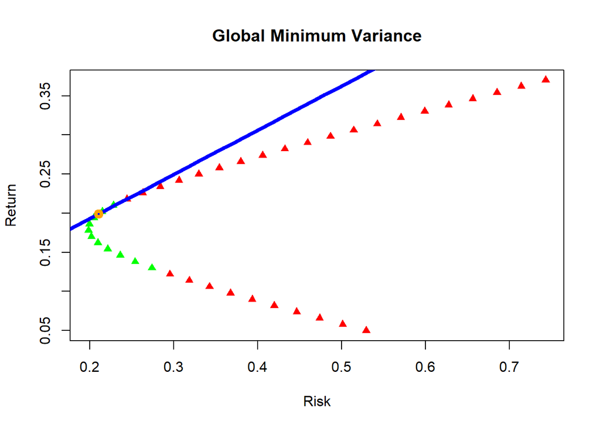

```r
# Plot of the efficient frontier, assume no short sale allowed
plot(riskWithShort, returnWithShort, main='Global Minimum Variance', xlab = 'Risk', ylab = 'Return', col = 'red', pch = 17)
points(riskWithoutShort, returnWithoutShort, col = 'green', pch = 17)
plot.function(CAL, add= TRUE, col = 'blue', lwd = 4)
points(sigma, Rp, col='orange', lwd = 4)
```

## f. **What will be the expected return to portfolio if the investor is willing to take 25% risk?**

At 25% risk, the expected return is:

$$\begin{equation}
\begin{aligned}
E(R_p) & = r_f + Slope_{CAL} * x \\
& = 0.08 + 0.5649447 * .25 \\
& = 0.2212362 \\
& = 22.1236169 \%
\end{aligned}
\end{equation}$$